# Predição do risco de evasão universitária no curso de graduação em Letras da Universidade de São Paulo

Conversões das datas:

```r
data$dtaing = as.Date(data$dtaing, format = '%Y-%m-%d')
data$dtanas = as.Date(data$dtanas, format = '%Y-%m-%d')
```

Há um problema quando a dummização não é feita manualmente a função step não consegue remover betas que não são significantes, então temos que dummizar manualmente:

```r
library(fastDummies)
colunas = c("sexo","cor","ec")
data <- dummy_cols(data, select_columns = colunas,
                           remove_selected_columns = T,
                           remove_most_frequent_dummy = T)
```

```r
library(lubridate)
evadidos_by_year = data |>
  filter(evadido == "sim") |>
  mutate(year = year(dtaing)) |>
  group_by(year) |>
  summarise(total_evadidos = n())
```

```r
nao_evadidos_by_year = data |>
  filter(evadido == "não") |>
  mutate(year = year(dtaing)) |>
  group_by(year) |>
  summarise(total_nao_evadidos = n())
```

```r
by_year = merge(x = evadidos_by_year, y = nao_evadidos_by_year, by = "year")
```

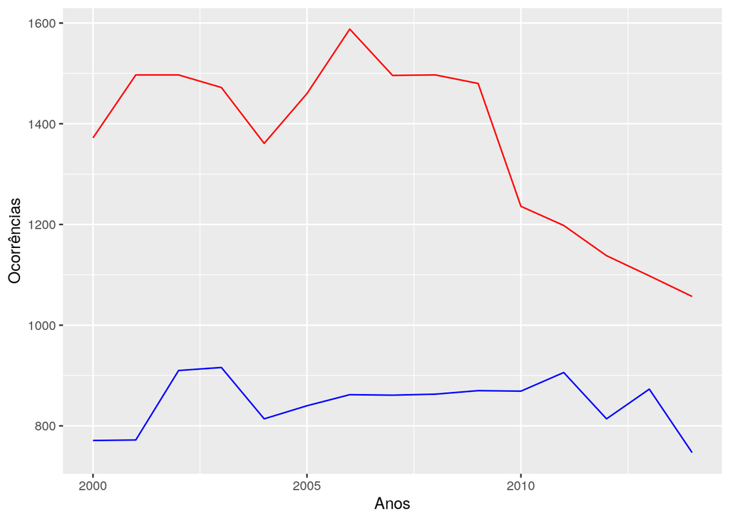

```r
ggplot() +
  geom_line(data = by_year, aes(x = year, y = total_evadidos), color = "blue") +
  geom_line(data = by_year, aes(x = year, y = total_nao_evadidos), color = "red") +
  xlab('Anos') +
  ylab('Ocorrências')
```

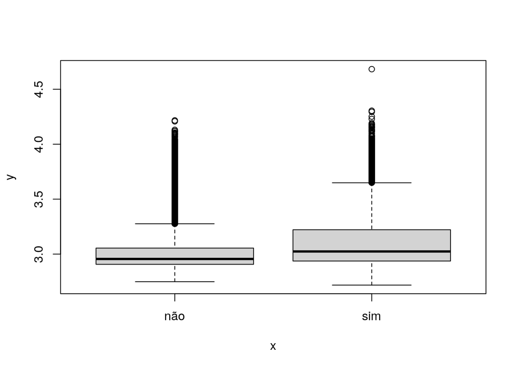

```r
plot(data$evadido,log(data$idade))
```

Fazer um teste estatístico entre a média dos evadidos e dos não evavidos?

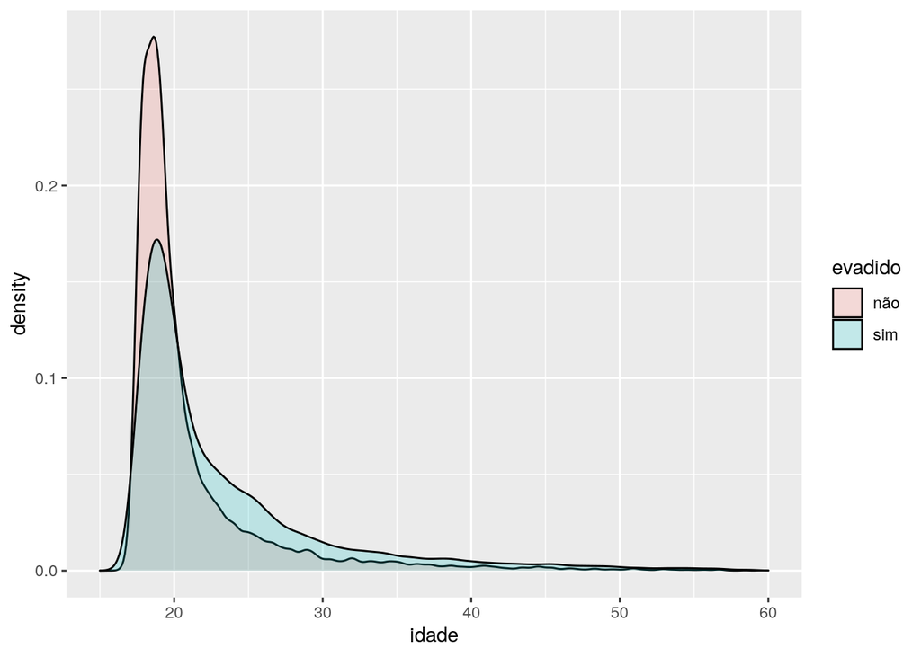

```r
library(tidyverse)
ggplot(data, aes(idade, fill = evadido)) +
  geom_density(alpha = 0.2) +
  xlim(15, 60)
```

plot temporal da evasão

# Introdução

A evasão na graduação universitária é um problema global e de difícil solução. O impacto negativo da evasão universitária não se limita à vida privada dos indivíduos desistentes, mas afeta também a instituição de ensino, a sociedade, a economia e o Estado, pois ao mesmo tempo em que o investimento monetário (público e/ou individual) se dissipa, a sociedade não recebe o retorno, em suas diversas manifestações, do esforço e investimento público empregado na formação educacional dos indivíduos evadidos (RODRIGUES; MORAES, 2021).

A evasão representa um problema em todas fases do processo educacional. LOPES FILHO; SILVEIRA (2021) fez um levantamento sistemático sobre a evasão no contexto de escolas secundárias do Brasil e com o auxílio de *Ciência de Dados* construiu modelos que fornecem probabilidades de alunos evadirem, baseando-se nos dados históricos de concluintes e evadidos. Internacionalmente tais modelos são conhecidos como *Early Warning System (EWS)*. Ainda segundo LOPES FILHO; SILVEIRA (2021), no contexto de escola secundárias, simples intervenções, como contato telefônico, podem dimunuir a probabilidade de evasão em muitos casos. Já no contexto universitário, a identificação precoce de indivíduos na graduação com alta probabilidade de evasão poderia ajudar gestores na criação de estratégias para mitigar ou ao menos minimizar o problema.

O uso de técnicas de *Machine Learning (ML)* tem ganhado espaço na última década no contexto de predição de evasão (MDUMA; KALEGELE; MACHUVE, 2019). A qualidade dos dados educacionais ainda é fator limitante para criação de modelos com alto poder preditivo (RAFIQ; RABBI; AHAMMAD, 2021), apesar disso, pesquisas com esse enfoque têm encontrado altas taxas de acurácias na previsão de evasão. Como o trabalho desenvolvido por RODRIGUES; MORAES (2021) que utilizando dados de instituições de ensino superior federais brasileiras criou modelos de *ML* para previsão de evasão com taxas 82,2% de acurácia.

A investigação da motivação para ocorrência de evasão na literatura científica pode ser olhada com a ótica de diversas áreas do conhecimento, como psicologia ou sociologia, mas de forma simplificada podemos agrupar os motivos de evasão em três categorias: fatores internos à instituição de ensino; fatores externos à instituição de ensino; e fatores individuas. As variáveis preditivas que contribuem para evasão podem ser de difícil acesso dependendo do grupo que estamos interessado, pois podem não existir, ou porque não estão sistematizadas. No geral, as variáveis explicativas relativas a instituição de ensino são as de mais fácil acesso por estarem organizadas para funcionameto de sistemas de controle academico.

No Brasil, trabalhos como o de DIGIAMPIETRI; NAKANO; SOUZA LAURETTO (2016) ou JESUS; RODRIGUEZ; JUNIOR (2021) aplicaram técnicas de ML para predição de evasão em cursos de graduação na área de exatas. Na literatura científica recente ainda são poucas análises similares com cursos da área de humanidades. Este projeto se propõe a investigar numa perspectiva de *Ciência de Dados* o fenômeno da evasão de discentes do curso de Letras da Universidade de São Paulo, com enfoque nos três primeiros anos do curso.

O problema de pesquisa que motiva a elaboração desse Trabalho de Conclusão de Curso (TCC) consiste em prover possíveis caminhos e sugestões para que atores envolvidos no processo educacional possam desenvolver estratégias para lidar com a problemática da evasão universitária, usando para tal, o ferramental provido por técnicas de Ciência de Dados.

# Material e Métodos

Serão analisados dados do banco de dados do sistema administrativo que opera a gestão de discentes do curso de Letras da *Faculdade de Filosofia, Letras e Ciências Humanas (FFLCH)* da *Universidade de São Paulo(USP)*, com recorte de 15 anos, com discente que ingressaram a partir de 2000 até 2014. Esse banco de dados relacional está normalizado e é base para diversos sistemas que operam o vínculo entre discente e instituição de ensino e contém portanto informações detalhadas desde o início do vínculo até a fim, seja o aluno evadido ou não. Contém ainda alguns dados pregressos ao vínculo, como tipo de instituição de ensino da escola secundária, notas em exames de ingresso, entre outros. A definição de variáveis preditivas é uma etapa importante e crucial para a construção do modelo (Mduma, 2019), neste caso, cada definição exige o mapeamento da variável e a realização do processo de de-normalização para prepará-la na inclusão do modelo. Assim, o projeto será organizado nas seguintes etapas:

Fase 1: Mapeamento da fonte de dados: estudo da estrutura atual dos dados, criação de consultas e scripts para automação da extração dos dados e prepará-los em um formato tabular, processo conhecido como ETL (Extract, Transform and Load). Possíveis informações individuas dos discentes que serão usadas como preditivas: turno, notas média em disciplinas obrigatórias aprovadas no primeiro ano, quantidade de reprovações no primeiro ano, idade, renda familiar no ingresso, tipo de ingresso, nota normalizada no ingresso, tipo de escola secundária, gênero declarado, estado civil, realização de estágio remunerado pela universidade, auxilio do tipo permanência estudantil, residência em termos da região censitária.

Fase 2: Pré-processamento dos dados: análise descritiva e sumarização dos dados, tomada de decisões como qual técnica empregar para lidar com dados faltantes. Possíveis remoções de colunas anteriormente selecionadas.

Fase 3: Extração do conhecimento: Aplicação de modelos de Machine Learning. Avaliação dos parâmetros e respectivos testes estatísticos.

Fase 4: Validação: análise do conhecimento obtido, avaliação do algoritmo treinado a partir da acurácia. Julgamento conceitual e subjacente dos resultados e comparação com a literatura científica correlata.

## Regressão logística

Dada que o fenômeno estudado tem natureza qualitativa sendo a variável dependente categórica (evadido ou não evadido) e dicotomica aplicaremos o método de regressão logistica binária. A ocorrência do evento será considerada a situação do discente evadir do curso e a não ocorrência do evento será quando o aluno não evadir do curso. Estamos interessados em avaliar a probabilidade de ocorrência do evento ($p_i$) evasão a partir do comportamento das variáveis explicativas ($x_i$):

$$Z_i = \alpha + {\beta_1x_1}_i + {\beta_2x_2}_i + ... + {\beta_kx_k}_i$$
Sendo o subscrito $i$ cada observação das $k$ variáveis explicativas e $Z_i$ é uma variável artificial comumente chamada de *logito* que nasce de uma manipulação matemática criada para tornar a variável dependente da equação acima com domínio de menos infinito até infinito. Para encontrarmos de fato a probabilidad de ocorrência do evento assumimos que $Z_i$ é dado pelo logaritmo natural da chance:

$Z_i = ln(\frac{p_i}{1-p_i})$

Isolando o probabibilidade em função logito chegamos à:

$p = \frac{1}{1+e^{-Z}}$

# Resultados Preliminares

### Análise Descritiva

Variáveis preditivas:

- idade: Idade no momento do ingresso
- sexo: Sexo ?
- cor: Raça/Cor ?
- ec: Estado cívil
- ay1: Quantidade de auxílios estudantis no primeiro ano da graduação
- ay2: Quantidade de auxílios estudantis no segundo ano da graduação
- ay3: Quantidade de auxílios estudantis no terceiro ano da graduação
- o1a: Quantidade de aprovações em disciplinas obrigatórias no primeiro ano da graduação
- o2a: Quantidade de aprovações em disciplinas obrigatórias no segundo ano da graduação
- o3a: Quantidade de aprovações em disciplinas obrigatórias no terceiro ano da graduação
- no1a: Quantidade de aprovações em disciplinas não obrigatórias no primeiro ano da graduação
- no2a: Quantidade de aprovações em disciplinas não obrigatórias no segundo ano da graduação
- no3a: Quantidade de aprovações em disciplinas não obrigatórias no terceiro ano da graduação
- o1r: Quantidade de reprovações em disciplinas obrigatórias no primeiro ano da graduação
- o2r: Quantidade de reprovações em disciplinas obrigatórias no segundo ano da graduação
- o3r: Quantidade de reprovações em disciplinas obrigatórias no terceiro ano da graduação
- no1r: Quantidade de reprovações em disciplinas não obrigatórias no primeiro ano da graduação
- no2r: Quantidade de reprovações em disciplinas não obrigatórias no segundo ano da graduação
- no3r: Quantidade de reprovações em disciplinas não obrigatórias no terceiro ano da graduação

Os auxílios tem entre 6 meses e 1 anos de duração.

[output not shown]

A final da pesquisa com o algoritmo treinado estimaremos a chance de evasão dos discentes atualmente em curso. Além da chance de evasão, identificaremos variáveis preditivas com maior ou menor peso nesta chance, informações essas extremamente valiosas para gestores sob uma ótica institucional, pois a gestão educacional é tradicionalmente responsável como agente de criação de estratégias, mas sob a ótica da área de pesquisa Learning Analytics (FERGUSON, 2012) devemos considerar não só gestores, mas sim todos atores do processo, como docentes, apoio administrativo, alunos e no limite a própria sociedade. Portanto, o resultado dos modelos empregados, no limite, pode servir de base estratégica para diminuição da problemática da evasão por todos atores do processo educacional.

### modelo

Colunas que não devemos considerar:

```r
not_cols = c('codpes','codpgm','dtaing','tiping','tipencpgm',
             'vinpgm', 'dtanas','codpasnac','codpasnas',
             'approvals_in_first_year','approvals_in_second_year','approvals_in_third_year',
             'failures_in_first_year','failures_in_second_year','failures_in_third_year')
data_glm = data[,!(names(data) %in% not_cols)]
```

```r
modelo_completo = glm(formula = evadido ~ ., data=data_glm, family = binomial)
summary(modelo_completo)
```

```
##
## Call:
## glm(formula = evadido ~ ., family = binomial, data = data_glm)
##
## Deviance Residuals:
##     Min       1Q   Median       3Q      Max
## -3.5600  -0.7370  -0.6129   0.8178   2.8435
##
## Coefficients:
##                              Estimate Std. Error z value Pr(>|z|)
## (Intercept)                 -2.534130   0.055235 -45.879  < 2e-16 ***
## idade                        0.049830   0.002339  21.306  < 2e-16 ***
## o1a                          0.193312   0.004905  39.412  < 2e-16 ***
## o1r                          0.500556   0.012120  41.300  < 2e-16 ***
## no1a                        -0.044360   0.023645  -1.876  0.06065 .
## no1r                         0.382360   0.059356   6.442 1.18e-10 ***
## o2a                         -0.024131   0.005791  -4.167 3.08e-05 ***
## o2r                          0.163375   0.012557  13.011  < 2e-16 ***
## no2a                        -0.102995   0.015461  -6.662 2.71e-11 ***
## no2r                         0.084849   0.041557   2.042  0.04118 *
## o3a                         -0.145121   0.006065 -23.927  < 2e-16 ***
## o3r                          0.062545   0.013048   4.793 1.64e-06 ***
## no3a                        -0.152390   0.009947 -15.320  < 2e-16 ***
## no3r                         0.124996   0.028200   4.432 9.32e-06 ***
## ay1                         -0.038887   0.030039  -1.295  0.19548
## ay2                         -0.050575   0.038308  -1.320  0.18676
## ay3                         -0.028241   0.034096  -0.828  0.40751
## sexo_M                      -0.142223   0.027347  -5.201 1.99e-07 ***
## cor_Amarela                  0.037653   0.055233   0.682  0.49542
## cor_Indígena                -0.123694   0.224799  -0.550  0.58215
## `cor_Não informada`          0.164784   0.060027   2.745  0.00605 **
## cor_Parda                   -0.073787   0.044056  -1.675  0.09396 .
## `cor_Preta / negra`         -0.052999   0.085523  -0.620  0.53545
## ec_Casado                   -0.497211   0.060067  -8.278  < 2e-16 ***
## ec_Divorciado               -0.473480   0.189518  -2.498  0.01248 *
## ec_Outro                     0.412746   0.074061   5.573 2.50e-08 ***
## `ec_Separado judicialmente` -0.390185   0.228167  -1.710  0.08725 .
## `ec_União Estável`          -0.335996   0.363263  -0.925  0.35500
## ec_Viúvo                    -0.387309   0.547599  -0.707  0.47939
## ---
## Signif. codes:  0 '***' 0.001 '**' 0.01 '*' 0.05 '.' 0.1 ' ' 1
##
## (Dispersion parameter for binomial family taken to be 1)
##
##     Null deviance: 44101  on 33134  degrees of freedom
## Residual deviance: 34385  on 33106  degrees of freedom
## AIC: 34443
##
## Number of Fisher Scoring iterations: 5
```

```r
logLik(modelo_completo)
```

```
## 'log Lik.' -17192.51 (df=29)
```

```r
modelo_step = step(object = modelo_completo, k = qchisq(p=0.05, df =1, lower.tail = FALSE))
```

```
## Start:  AIC=34496.42
## evadido ~ idade + o1a + o1r + no1a + no1r + o2a + o2r + no2a +
##     no2r + o3a + o3r + no3a + no3r + ay1 + ay2 + ay3 + sexo_M +
##     cor_Amarela + cor_Indígena + `cor_Não informada` + cor_Parda +
##     `cor_Preta / negra` + ec_Casado + ec_Divorciado + ec_Outro +
##     `ec_Separado judicialmente` + `ec_União Estável` + ec_Viúvo
##
##                               Df Deviance   AIC
## - cor_Indígena                 1    34385 34493
## - `cor_Preta / negra`          1    34385 34493
## - cor_Amarela                  1    34385 34493
## - ec_Viúvo                     1    34386 34493
## - ay3                          1    34386 34493
## - `ec_União Estável`           1    34386 34493
## - ay1                          1    34387 34494
## - ay2                          1    34387 34494
## - cor_Parda                    1    34388 34495
## - `ec_Separado judicialmente`  1    34388 34496
## - no1a                         1    34389 34496
## <none>                              34385 34496
## - no2r                         1    34389 34497
## - ec_Divorciado                1    34391 34499
## - `cor_Não informada`          1    34393 34500
## - o2a                          1    34402 34510
## - no3r                         1    34405 34513
## - o3r                          1    34408 34516
## - sexo_M                       1    34412 34520
## - ec_Outro                     1    34415 34523
## - no1r                         1    34429 34536
## - no2a                         1    34430 34538
## - ec_Casado                    1    34457 34564
## - o2r                          1    34566 34673
## - no3a                         1    34628 34736
## - idade                        1    34855 34962
## - o3a                          1    34990 35098
## - o1a                          1    36048 36156
## - o1r                          1    36759 36866
##
## Step:  AIC=34492.88
## evadido ~ idade + o1a + o1r + no1a + no1r + o2a + o2r + no2a +
```

[output cut: 295 more lines]

```
## - ay2                  1    34414 34483
## - o2a                  1    34418 34487
## - no3r                 1    34420 34490
## - o3r                  1    34423 34492
## - sexo_M               1    34429 34499
## - ec_Outro             1    34431 34501
## - no1r                 1    34442 34511
## - no2a                 1    34458 34527
## - ec_Casado            1    34470 34539
## - o2r                  1    34581 34651
## - no3a                 1    34644 34713
## - idade                1    34867 34936
## - o3a                  1    35016 35086
## - o1a                  1    36065 36134
## - o1r                  1    36789 36858
```

```r
summary(modelo_step)
```

```
##
## Call:
## glm(formula = evadido ~ idade + o1a + o1r + no1r + o2a + o2r +
##     no2a + no2r + o3a + o3r + no3a + no3r + ay2 + sexo_M + `cor_Não informada` +
##     ec_Casado + ec_Divorciado + ec_Outro, family = binomial,
##     data = data_glm)
##
## Deviance Residuals:
##     Min       1Q   Median       3Q      Max
## -3.5575  -0.7376  -0.6120   0.8205   2.7816
##
## Coefficients:
##                      Estimate Std. Error z value Pr(>|z|)
## (Intercept)         -2.530656   0.054681 -46.280  < 2e-16 ***
## idade                0.049277   0.002320  21.239  < 2e-16 ***
## o1a                  0.193122   0.004899  39.418  < 2e-16 ***
## o1r                  0.500656   0.012089  41.413  < 2e-16 ***
## no1r                 0.373406   0.059166   6.311 2.77e-10 ***
## o2a                 -0.024348   0.005784  -4.210 2.56e-05 ***
## o2r                  0.163181   0.012545  13.008  < 2e-16 ***
## no2a                -0.111490   0.014933  -7.466 8.25e-14 ***
## no2r                 0.081175   0.041437   1.959 0.050110 .
## o3a                 -0.146092   0.006055 -24.126  < 2e-16 ***
## o3r                  0.061246   0.013035   4.699 2.62e-06 ***
## no3a                -0.152215   0.009932 -15.326  < 2e-16 ***
## no3r                 0.124458   0.028161   4.420 9.89e-06 ***
## ay2                 -0.103405   0.028428  -3.637 0.000275 ***
## sexo_M              -0.146538   0.027288  -5.370 7.87e-08 ***
## `cor_Não informada`  0.158838   0.059056   2.690 0.007153 **
## ec_Casado           -0.488544   0.059891  -8.157 3.43e-16 ***
## ec_Divorciado       -0.463476   0.189200  -2.450 0.014299 *
## ec_Outro             0.415634   0.073991   5.617 1.94e-08 ***
## ---
## Signif. codes:  0 '***' 0.001 '**' 0.01 '*' 0.05 '.' 0.1 ' ' 1
##
## (Dispersion parameter for binomial family taken to be 1)
##
##     Null deviance: 44101  on 33134  degrees of freedom
## Residual deviance: 34401  on 33116  degrees of freedom
## AIC: 34439
##
## Number of Fisher Scoring iterations: 5
```

```r
logLik(modelo_step)
```

```
## 'log Lik.' -17200.26 (df=19)
```

Teste qui-quadrado comparando as diferenças entre os loglik:

```r
library(lmtest)
lrtest(modelo_completo, modelo_step)
```

|  | #Df | LogLik | Df | Chisq | Pr(>Chisq) |
| --- | --- | --- | --- | --- | --- |
| 1 | 29 | -17192.51 | NA | NA | NA |
| 2 | 19 | -17200.26 | -10 | 15.50227 | 0.1147947 |

Hipótese Nula: A diferença entre os loglik dos dois modelo é nula, ou seja, os dois modelos são estatisticamente iguais

Hipótese Alternativa: A diferença entre os loglik dos dois modelo **não** é nula, ou seja, os dois modelos são estatisticamente diferentes

## Significância estatística geral do modelo

O teste $\chi^2$ é adequado para modelos com parametros estimados pelo método de máxima verossimilhança e o usaremos para avaliação da significancia estistica global do modelo, ou seja, considerando o conjunto de variáveis explicaticas. Segue a elaboração da hipótese nula e alternativa:

A hipótese nula será aquela em que nenhuma das variáveis preditivas são estatisticamente significante para explicar a probabilidade de evasão:

- $H_0: \beta_1 = \beta_2 ... \beta_k = 0$

A hipótese alterativa será aquela ao menos uma das variáveis preditivas é estatisticamente significante para explicar a probabilidade de evasão:

Cálculo do qui-quadrado:

$\chi^2 = -2(LL_0 - LL_{max})$

Modelo nulo, aquele que só contém a constanste alfa e nenhum beta:

```r
modelo_nulo = glm(formula = evadido ~ 1,data=data_glm, family = binomial)
qui_quadrado = -2*(logLik(modelo_nulo) - logLik(modelo_step))
qui_quadrado
```

```
## 'log Lik.' 9700.496 (df=1)
```

```r
pchisq(qui_quadrado, df =19, lower.tail = F)
```

```
## 'log Lik.' 0 (df=1)
```

com p-value foi 0 pelo menos um beta foi estatisticamente para explicar a probabilidade de ocorrência de evasão

phat = probabilidade ajustada

```r
data$phat = modelo_step$fitted.values
```

Agora temos que definir um ponto de corte (cutoff)

- evento acontece se phat >= cutoff
- evento não acontece se phat < cutoff

```r
cutoff = 0.5
```

Matriz de confusão ou matriz de classificação:

```r
library(caret)
tabela = table(preditos = data$phat >cutoff, medidos = data$evadido == "sim" )
tabela = tabela[2:1,2:1]
confusionMatrix(tabela)
```

```
## Confusion Matrix and Statistics
##
##         medidos
## preditos  TRUE FALSE
##    TRUE   6848  2189
##    FALSE  5840 18258
##
##                Accuracy : 0.7577
##                  95% CI : (0.753, 0.7623)
##     No Information Rate : 0.6171
##     P-Value [Acc > NIR] : < 2.2e-16
##
##                   Kappa : 0.4577
##
##  Mcnemar's Test P-Value : < 2.2e-16
##
##             Sensitivity : 0.5397
##             Specificity : 0.8929
##          Pos Pred Value : 0.7578
##          Neg Pred Value : 0.7577
##              Prevalence : 0.3829
##          Detection Rate : 0.2067
##    Detection Prevalence : 0.2727
##       Balanced Accuracy : 0.7163
##
##        'Positive' Class : TRUE
##
```

Sensitivity : Taxa de acerto do modelo para as observações classificadas como “evento”.  
Specificity : Taxa de acerto do modelo para as observações classificadas como “não evento”.

Análise de sensibilidade:

```r
library(ROCR)
predicoes = prediction(predictions = modelo_step$fitted.values, labels = data$evadido)
sensitividade_roc = performance(predicoes, measure = "sens")
especificidade_roc = performance(predicoes, measure = "spec")
sensitividade = sensitividade_roc@y.values[[1]]
especificidade = especificidade_roc@y.values[[1]]
cutoffs = sensitividade_roc@x.values[[1]]
dados_plotagens = data.frame(cutoffs,sensitividade,especificidade)
```

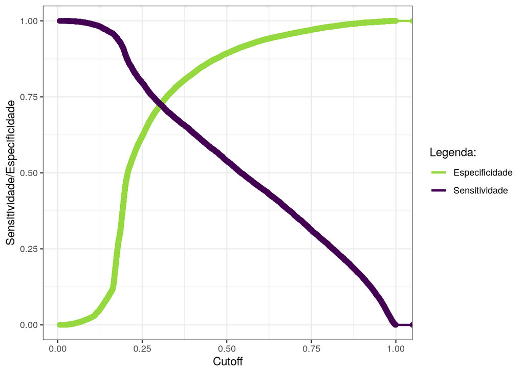

```r
library(tidyverse)
ggplot(data=dados_plotagens, aes(x = cutoffs, y = especificidade)) +
 geom_line(aes(color = "Especificidade"),
           size = 1) +
 geom_point(color = "#95D840FF",
            size = 1.9) +
 geom_line(aes(x = cutoffs, y = sensitividade, color = "Sensitividade"),
           size = 1) +
 geom_point(aes(x = cutoffs, y = sensitividade),
            color = "#440154FF",
            size = 1.9) +
 labs(x = "Cutoff",
      y = "Sensitividade/Especificidade") +
 scale_color_manual("Legenda:",
                    values = c("#95D840FF", "#440154FF")) +
 theme_bw()
```

A intersecção não necessariamente maxima a acurácia.

Curva ROC (receiver operating caracteristic), eficiência global do modelo independente do cutoff.

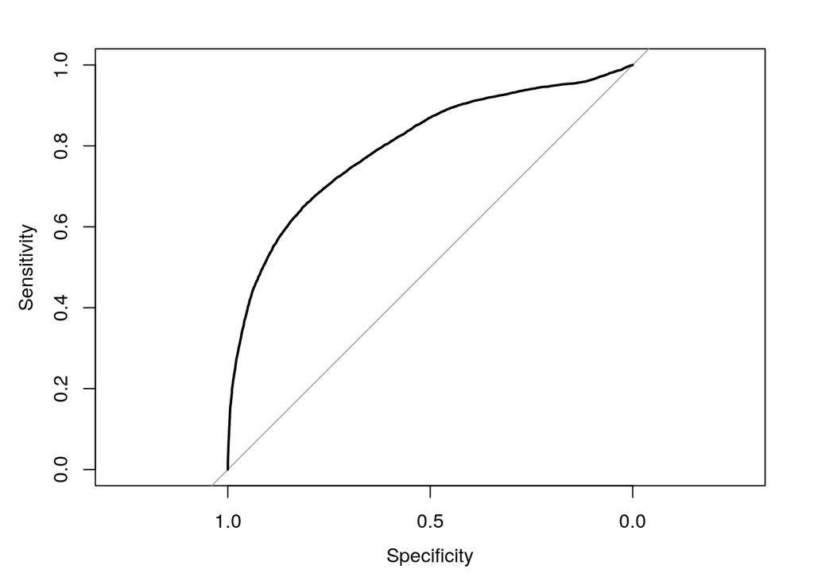

```r
library(pROC)
roc = roc(predictor = data$phat, response = data$evadido)
plot(roc)
```

Mesmo gráfico usando ggplot:

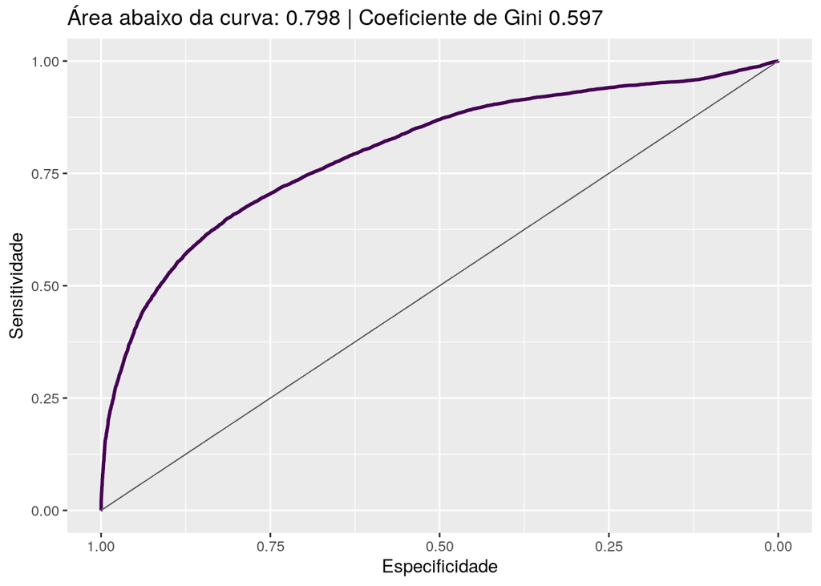

```r
library(tidyverse)
ggroc(roc, color = "#440154FF", size = 1) +
  geom_segment(aes(x = 1, xend = 0, y = 0, yend = 1),
               color="grey40",
               size = 0.2) +
  labs(x = "Especificidade",
       y = "Sensitividade",
       title = paste("Área abaixo da curva:",
                     round(roc$auc, 3),
                     "|",
                     "Coeficiente de Gini",
                     round((roc$auc[1] - 0.5) / 0.5, 3)))
```

Vamos sempre escolher o modelo com maior área abaixo da curva roc, que no geral é o modelo com maior LL.

E como aumentamos a área em baixo da curva ROC? Aumentando a quantidade de parametro X cujo os parâmetros se mostraram estatisticamente significantes após o stepwise.

Coeficiente de Gini: (roc-0.5)/0.5, outro indicador… redundante, pois a área abaixo de roc da a mesma informação.

podemos comparar modelo com sensitividade, sensibilidade e acurácia para o MESMO cutoff

ROC: Entretanto a área abaixo da curva ROC da a eficiência do modelo independente do cutoff

quando a proporção de evento/não evento é diferente na amostra coletada da população devemos corrigir o alfa por um método descrito por Anderson(1982)

```r
library(jtools)
summ(modelo_step, confint = T, digits = 4, ci.width = .95)
```

| Observations | 33135 |
| --- | --- |
| Dependent variable | evadido |
| Type | Generalized linear model |
| Family | binomial |
| Link | logit |

| 𝛘²(18) | 9700.4964 |
| --- | --- |
| Pseudo-R² (Cragg-Uhler) | 0.3449 |
| Pseudo-R² (McFadden) | 0.2200 |
| AIC | 34438.5152 |
| BIC | 34598.2738 |

|  | Est. | 2.5% | 97.5% | z val. | p |
| --- | --- | --- | --- | --- | --- |
| (Intercept) | -2.5307 | -2.6378 | -2.4235 | -46.2800 | 0.0000 |
| idade | 0.0493 | 0.0447 | 0.0538 | 21.2387 | 0.0000 |
| o1a | 0.1931 | 0.1835 | 0.2027 | 39.4178 | 0.0000 |
| o1r | 0.5007 | 0.4770 | 0.5244 | 41.4135 | 0.0000 |
| no1r | 0.3734 | 0.2574 | 0.4894 | 6.3112 | 0.0000 |
| o2a | -0.0243 | -0.0357 | -0.0130 | -4.2098 | 0.0000 |
| o2r | 0.1632 | 0.1386 | 0.1878 | 13.0076 | 0.0000 |
| no2a | -0.1115 | -0.1408 | -0.0822 | -7.4662 | 0.0000 |
| no2r | 0.0812 | -0.0000 | 0.1624 | 1.9590 | 0.0501 |
| o3a | -0.1461 | -0.1580 | -0.1342 | -24.1264 | 0.0000 |
| o3r | 0.0612 | 0.0357 | 0.0868 | 4.6985 | 0.0000 |
| no3a | -0.1522 | -0.1717 | -0.1327 | -15.3260 | 0.0000 |
| no3r | 0.1245 | 0.0693 | 0.1797 | 4.4195 | 0.0000 |
| ay2 | -0.1034 | -0.1591 | -0.0477 | -3.6374 | 0.0003 |
| sexo_M | -0.1465 | -0.2000 | -0.0931 | -5.3701 | 0.0000 |
| `cor_Não informada` | 0.1588 | 0.0431 | 0.2746 | 2.6896 | 0.0072 |
| ec_Casado | -0.4885 | -0.6059 | -0.3712 | -8.1572 | 0.0000 |
| ec_Divorciado | -0.4635 | -0.8343 | -0.0927 | -2.4497 | 0.0143 |
| ec_Outro | 0.4156 | 0.2706 | 0.5607 | 5.6173 | 0.0000 |

Standard errors: MLE

sigmódide:

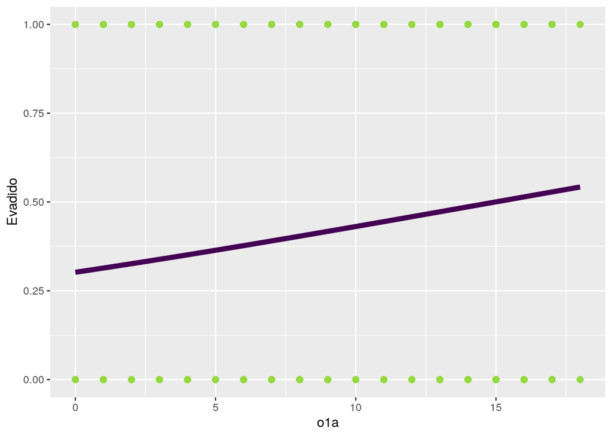

```r
library(tidyverse)
novo = data
novo$phat = modelo_step$fitted.values
novo$evadido = as.numeric(novo$evadido) - 1
ggplot(data=novo) +
geom_point(aes(x = o1a, y = evadido), color = "#95D840FF", size = 2) +
geom_smooth(aes(x = o1a, y = phat),
            method = "glm", formula = y ~ x,
            method.args = list(family = "binomial"),
            se = F,
            color = "#440154FF", size = 2) +
labs(x = "o1a",
     y = "Evadido")
```

# Referências Bibliográficas

DIGIAMPIETRI, Luciano Antonio; NAKANO, Fabio; SOUZA LAURETTO, Marcelo De. Mineraçao de dados para identificaçao de alunos com alto risco de evasao: Um estudo de caso. **Revista de Graduação USP**, *[S. l.]*, v. 1, n. 1, p. 17–23, 2016.

FERGUSON, Rebecca. Learning analytics: drivers, developments and challenges. **International Journal of Technology Enhanced Learning**, *[S. l.]*, v. 4, n. 5-6, p. 304–317, 2012.

JESUS, Hiago Oliveira De; RODRIGUEZ, Luis Cuevas; JUNIOR, Almir de Oliveira Costa. Predição de Evasão Escolar na Licenciatura em Computação. **Revista Brasileira de Informática na Educação**, *[S. l.]*, v. 29, p. 255–272, 2021.

LOPES FILHO, José Ahirton Batista; SILVEIRA, Ismar Frango. Detecção precoce de estudantes em risco de evasão usando dados administrativos e aprendizagem de máquina. **Revista Ibérica de Sistemas e Tecnologias de Informação**, *[S. l.]*, n. E40, p. 480–495, 2021.

MDUMA, Neema; KALEGELE, Khamisi; MACHUVE, Dina. Machine learning approach for reducing students dropout rates. *[S. l.]*, 2019.

RAFIQ, Md Abdur; RABBI, Abir Mahamud; AHAMMAD, Rasel. A data science approach to Predict the University Students at risk of semester dropout: Bangladeshi University Perspective. *In*: 2021 5TH INTERNATIONAL CONFERENCE ON TRENDS IN ELECTRONICS AND INFORMATICS (ICOEI) 2021, **Anais** [...]. : IEEE, 2021. p. 1350–1354.

RODRIGUES, Leonardo Martins; MORAES, Emerson Augusto Priamo. Análise preditiva para identificação de alunos suscetı́veis à evasão escolar Análise preditiva para identificação de alunos suscetı́veis à evasão escolar. **Brazilian Journal of Development**, *[S. l.]*, v. 7, n. 7, p. 71631–71643, 2021.